# Historie

*Zpětná vazba, júlový turnus Discover*

## Hodnocení kurzu

Průměrná známka:

| Blok setkání | Průměrná známka |
| --- | --- |
| B | 1.33 |

### Hodnocení po dnech

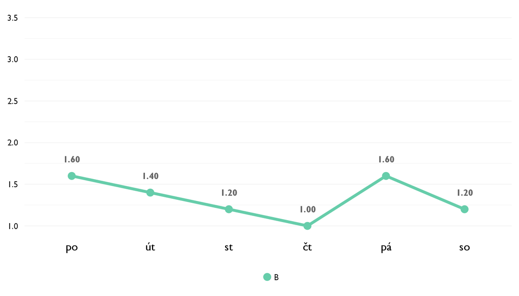

### Co se na kurzu líbilo

- Na vsechno jsme si museli prijit sami, obhajit si to a take tam byl vzdy patrny presah do soucasneho a budouciho zivota ve vsech ohledech.
- Vše se mi líbilo.
- Látka bola rozdielna od tých v škole. Ňeučil som sa fakty, ale samotný pohľad na históriu, čo mi nadmieru vyhovovalo.
- najvice se mi libilo kdyz sme s ucili o tom jak kdysi fungovali imperia, a hlavne jak fungovalo saladinovo imperium
- Iný spůsob vnímania histórie.

### Co na kurzu změnit

- Nic.
- Na kurzu není potřeba měnit naprosto nic.
- Kurz bol pútavý a informácie, ktoré poskytuje sú dostatočne užitočné.
- asi nic, cekala jsem vice fakt ale milo mne to prekvapilo
- Viac zaujímavých tém.

## Hodnocení lektora

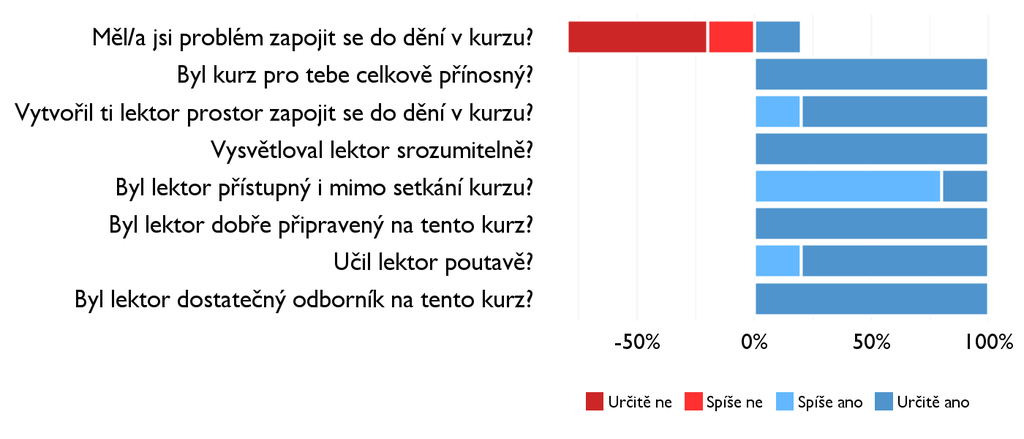

### Komentáře k lektorovi

- bylo to supeeer
- -

## Náročnost kurzu

### **Jak hodnotíš náročnost…**

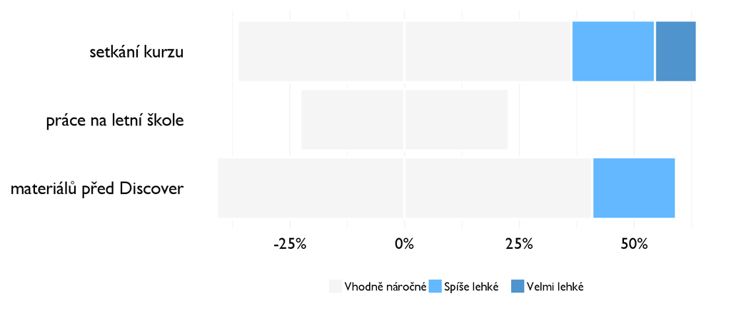

## Didaktika

### Jak lektor učí a měl by to změnit?

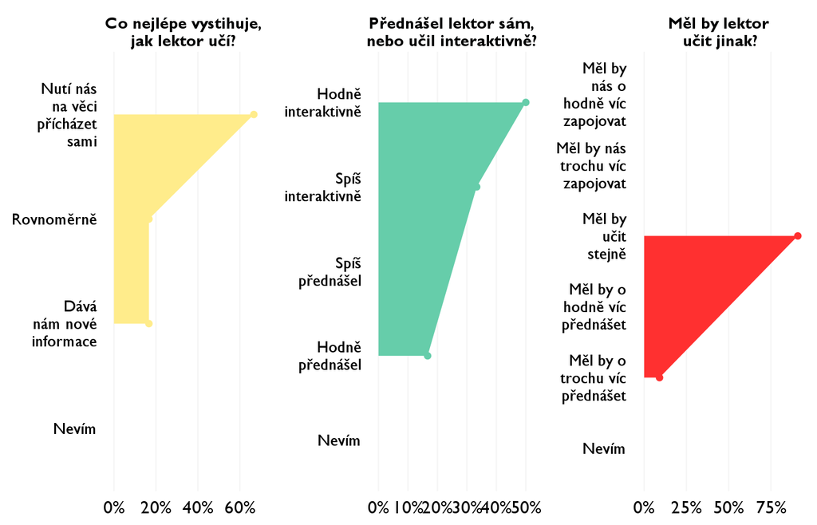

### Jak se studentům nejlépe učí?

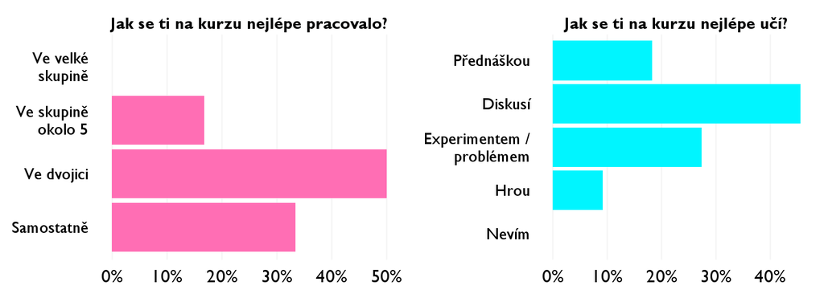

## Ovlivnil tě kurz nějak?

**Pokud ano, jak? Pokud ne, proč ne?**

- V pohledu na svet a na zivot jako takovy. V pohledu na Historii jako vedu samotnou - historie muze byt vyucovana i zabavne a spoustu veci se da naucit v 5 minutach.
- Naučil mě přemýšlet o faktch jinak. Veškerý feedback jsme si řekli již v poslední hodině.
- Ako som už napísal, môj pohľad na históriu sa zásadne zmenil. Spôsob, akým sa zaznamenáva história je iný, ako som si myslel.
- naucil mne ze to co jsem vnimala jako pevne stanovena fakta ve skutecnosti nejsou vubec definovatelni a ze na vsechno musim zhlizet aspon trochu kriticky
- Iné vnímanie faktov a iný postoj na hodinách dejepisu.